# Introduction

Whatever the size of your business, ensuring that it's successful or not is important to calculate the feasibility of its future, or just to give an insight into how effective it is and JustDice GmbH is no different. For example, some of the processes may need to be changed to make the business more profitable. Success can be measured in a number of different ways, and it's important to remember that what success means for one business, might not be the same for any other business.Success is often measured based on a number of realistic targets. These are often known as KPIs (key performance indicators). They are unique for each business because every business is different and will measure success in different ways.A company's success is often associated with its sales revenues and profits.Essentially for a company like JustDice GmbH to be profitable , the revenue must be more than the Expenses.From the data we will be looking at the total revenues against the expenses and use that to calculate the profits amongst other KPI's we will be looking at.

# Analysis

```python
import pandas as pd
import seaborn as sns
import numpy as np
import matplotlib
import matplotlib.pyplot as plt
from mpl_toolkits.mplot3d import Axes3D
```

```python
df=pd.read_csv('adspend.csv')
df
```

|  | event_date | country_id | network_id | client_id | value_usd |
| --- | --- | --- | --- | --- | --- |
| 0 | 2022-01-01 | 1 | 10 | 71 | 4.680000 |
| 1 | 2022-01-01 | 1 | 10 | 94 | 223.439997 |
| 2 | 2022-01-01 | 1 | 10 | 104 | 0.800000 |
| 3 | 2022-01-01 | 1 | 10 | 121 | 4.870000 |
| 4 | 2022-01-01 | 1 | 10 | 174 | 1.300000 |
| ... | ... | ... | ... | ... | ... |
| 11958 | 2022-12-31 | 109 | 60 | 121 | 0.297000 |
| 11959 | 2022-12-31 | 109 | 60 | 154 | 0.116000 |
| 11960 | 2022-12-31 | 109 | 60 | 174 | 1.457000 |
| 11961 | 2022-12-31 | 109 | 60 | 189 | 0.225000 |
| 11962 | 2022-12-31 | 109 | 60 | 256 | 0.075000 |

11963 rows × 5 columns

```python
df.info()
```

```
<class 'pandas.core.frame.DataFrame'>
RangeIndex: 11963 entries, 0 to 11962
Data columns (total 5 columns):
 #   Column      Non-Null Count  Dtype
---  ------      --------------  -----
 0   event_date  11963 non-null  object
 1   country_id  11963 non-null  int64
 2   network_id  11963 non-null  int64
 3   client_id   11963 non-null  int64
 4   value_usd   11963 non-null  float64
dtypes: float64(1), int64(3), object(1)
memory usage: 467.4+ KB
```

```python
df.describe()
```

|  | country_id | network_id | client_id | value_usd |
| --- | --- | --- | --- | --- |
| count | 11963.000000 | 11963.000000 | 11963.000000 | 11963.000000 |
| mean | 53.452395 | 40.815849 | 152.429324 | 21.238483 |
| std | 60.199879 | 24.315125 | 81.212289 | 65.157007 |
| min | 1.000000 | 10.000000 | 71.000000 | 0.000000 |
| 25% | 1.000000 | 10.000000 | 95.000000 | 0.510000 |
| 50% | 1.000000 | 60.000000 | 121.000000 | 1.300000 |
| 75% | 109.000000 | 60.000000 | 189.000000 | 6.677500 |
| max | 213.000000 | 60.000000 | 402.000000 | 1152.598013 |

```python
df.duplicated().sum()
```

```
0
```

```python
df.isnull().sum()
```

```
event_date    0
country_id    0
network_id    0
client_id     0
value_usd     0
dtype: int64
```

```python
b=pd.read_csv('installs.csv')
b
```

|  | install_id | country_id | app_id | network_id | event_date | device_os_version |
| --- | --- | --- | --- | --- | --- | --- |
| 0 | 6b168a9f7a13119b87bfeb834d159f6879ff000205cb27... | 1 | 174 | 26 | 2022-12-13 | 10 |
| 1 | 218ecd973c988fe76dfd247f92e9317485010844163a51... | 1 | 174 | 60 | 2022-12-14 | 10 |
| 2 | f67c1382fc3af8a24cb6f23bff381279d582eb67d4043e... | 17 | 122 | 26 | 2022-12-30 | 11 |
| 3 | afe4dc7c1663fba7ba3bc7cf6a308c38c1cb409d253f7f... | 1 | 121 | 1111 | 2022-12-30 | 8.0.0 |
| 4 | 417acac6a6bdb88a83371f8ab482691d16896e8681afcb... | 109 | 325 | 10 | 2022-12-05 | 11 |
| ... | ... | ... | ... | ... | ... | ... |
| 216883 | 19be0a9a4458de0d52547e141df90507cf6432ff8ac512... | 213 | 184 | 60 | 2022-01-08 | 10 |
| 216884 | a39a5e320f0cad2c67184302a1e5deeea9c12a1fa9a34d... | 109 | 121 | 60 | 2022-01-08 | 11 |
| 216885 | e6a9b7812608a10ba6a5c654e33ee2482a4e6cd4f9ec2f... | 109 | 121 | 26 | 2022-01-08 | 11 |
| 216886 | e0fd2cee99c16389dd64ba242471d5709f64033b03fb08... | 109 | 174 | 60 | 2022-01-08 | 10 |
| 216887 | d94f346409318fc80543a50254af51745fb8bf29ee0c4b... | 1 | 94 | 26 | 2022-01-08 | 10 |

216888 rows × 6 columns

```python
b.info()
```

```
<class 'pandas.core.frame.DataFrame'>
RangeIndex: 216888 entries, 0 to 216887
Data columns (total 6 columns):
 #   Column             Non-Null Count   Dtype
---  ------             --------------   -----
 0   install_id         216888 non-null  object
 1   country_id         216888 non-null  int64
 2   app_id             216888 non-null  int64
 3   network_id         216888 non-null  int64
 4   event_date         216888 non-null  object
 5   device_os_version  216888 non-null  object
dtypes: int64(3), object(3)
memory usage: 9.9+ MB
```

```python
b.duplicated().sum()
```

```
1
```

```python
b.isnull().sum()
```

```
install_id           0
country_id           0
app_id               0
network_id           0
event_date           0
device_os_version    0
dtype: int64
```

```python
b.drop_duplicates()
```

|  | install_id | country_id | app_id | network_id | event_date | device_os_version |
| --- | --- | --- | --- | --- | --- | --- |
| 0 | 6b168a9f7a13119b87bfeb834d159f6879ff000205cb27... | 1 | 174 | 26 | 2022-12-13 | 10 |
| 1 | 218ecd973c988fe76dfd247f92e9317485010844163a51... | 1 | 174 | 60 | 2022-12-14 | 10 |
| 2 | f67c1382fc3af8a24cb6f23bff381279d582eb67d4043e... | 17 | 122 | 26 | 2022-12-30 | 11 |
| 3 | afe4dc7c1663fba7ba3bc7cf6a308c38c1cb409d253f7f... | 1 | 121 | 1111 | 2022-12-30 | 8.0.0 |
| 4 | 417acac6a6bdb88a83371f8ab482691d16896e8681afcb... | 109 | 325 | 10 | 2022-12-05 | 11 |
| ... | ... | ... | ... | ... | ... | ... |
| 216883 | 19be0a9a4458de0d52547e141df90507cf6432ff8ac512... | 213 | 184 | 60 | 2022-01-08 | 10 |
| 216884 | a39a5e320f0cad2c67184302a1e5deeea9c12a1fa9a34d... | 109 | 121 | 60 | 2022-01-08 | 11 |
| 216885 | e6a9b7812608a10ba6a5c654e33ee2482a4e6cd4f9ec2f... | 109 | 121 | 26 | 2022-01-08 | 11 |
| 216886 | e0fd2cee99c16389dd64ba242471d5709f64033b03fb08... | 109 | 174 | 60 | 2022-01-08 | 10 |
| 216887 | d94f346409318fc80543a50254af51745fb8bf29ee0c4b... | 1 | 94 | 26 | 2022-01-08 | 10 |

216887 rows × 6 columns

```python
c=pd.read_csv('payouts.csv')
c
```

|  | install_id | event_date | value_usd |
| --- | --- | --- | --- |
| 0 | 8912076a49c7b17960f8d262dc37599f86cbb3da8912b6... | 2022-12-21 | 0.254376 |
| 1 | 7488c7b0f3d25cea61e435ea2aa346d3bbf1b946b94b1f... | 2022-12-28 | 0.361216 |
| 2 | 66ee0cd1d490d9d352b46b443c9d5b5aa5bdabfbdb303b... | 2022-12-10 | 0.359006 |
| 3 | 66ee0cd1d490d9d352b46b443c9d5b5aa5bdabfbdb303b... | 2022-12-10 | 0.253416 |
| 4 | 66ee0cd1d490d9d352b46b443c9d5b5aa5bdabfbdb303b... | 2022-12-10 | 0.253416 |
| ... | ... | ... | ... |
| 51998 | f280f52a3e6e7e105204ae6e5533bdcf149371807f1b5e... | 2022-01-26 | 1.910376 |
| 51999 | 5416f5bd483d76e684e0d3ed090fd10342c3168f0fa492... | 2022-01-27 | 0.383418 |
| 52000 | 4fb5afa7d5dfd772e84bae4979a64fdf9cea75420294f1... | 2022-01-26 | 0.757368 |
| 52001 | 4fb5afa7d5dfd772e84bae4979a64fdf9cea75420294f1... | 2022-01-26 | 0.384336 |
| 52002 | 8989b67fb9d253958513bc06ad7e80dca90e44b345f23a... | 2022-01-26 | 0.757368 |

52003 rows × 3 columns

```python
c.info()
```

```
<class 'pandas.core.frame.DataFrame'>
RangeIndex: 52003 entries, 0 to 52002
Data columns (total 3 columns):
 #   Column      Non-Null Count  Dtype
---  ------      --------------  -----
 0   install_id  52003 non-null  object
 1   event_date  52003 non-null  object
 2   value_usd   52003 non-null  float64
dtypes: float64(1), object(2)
memory usage: 1.2+ MB
```

```python
c.duplicated().sum()
```

```
11131
```

```python
c.drop_duplicates()
```

|  | install_id | event_date | value_usd |
| --- | --- | --- | --- |
| 0 | 8912076a49c7b17960f8d262dc37599f86cbb3da8912b6... | 2022-12-21 | 0.254376 |
| 1 | 7488c7b0f3d25cea61e435ea2aa346d3bbf1b946b94b1f... | 2022-12-28 | 0.361216 |
| 2 | 66ee0cd1d490d9d352b46b443c9d5b5aa5bdabfbdb303b... | 2022-12-10 | 0.359006 |
| 3 | 66ee0cd1d490d9d352b46b443c9d5b5aa5bdabfbdb303b... | 2022-12-10 | 0.253416 |
| 10 | b471322de9a2f2f164f0d5a8016cb6d4be41e9bde7e2d2... | 2022-12-10 | 3.558383 |
| ... | ... | ... | ... |
| 51998 | f280f52a3e6e7e105204ae6e5533bdcf149371807f1b5e... | 2022-01-26 | 1.910376 |
| 51999 | 5416f5bd483d76e684e0d3ed090fd10342c3168f0fa492... | 2022-01-27 | 0.383418 |
| 52000 | 4fb5afa7d5dfd772e84bae4979a64fdf9cea75420294f1... | 2022-01-26 | 0.757368 |
| 52001 | 4fb5afa7d5dfd772e84bae4979a64fdf9cea75420294f1... | 2022-01-26 | 0.384336 |
| 52002 | 8989b67fb9d253958513bc06ad7e80dca90e44b345f23a... | 2022-01-26 | 0.757368 |

40872 rows × 3 columns

```python
c.info()
```

```
<class 'pandas.core.frame.DataFrame'>
RangeIndex: 52003 entries, 0 to 52002
Data columns (total 3 columns):
 #   Column      Non-Null Count  Dtype
---  ------      --------------  -----
 0   install_id  52003 non-null  object
 1   event_date  52003 non-null  object
 2   value_usd   52003 non-null  float64
dtypes: float64(1), object(2)
memory usage: 1.2+ MB
```

```python
d=pd.read_csv('revenue.csv')
d
```

|  | install_id | event_date | value_usd |
| --- | --- | --- | --- |
| 0 | 213197bd66cd889d103ab9059709458e49808214837508... | 2022-12-16 | 1.58000 |
| 1 | 251442e25a39fb706e242445db49498ba1d6762c1ff46e... | 2022-12-21 | 6.75000 |
| 2 | 3e7bdaca309c5eea9d4004a0400b5a830f3963bddc71f8... | 2022-12-21 | 1.62000 |
| 3 | 9505bab0515c96b7d8c9a5aeb1fb28ae397b23badb2f03... | 2022-12-20 | 0.00150 |
| 4 | fa69bdded229f9ebb18290559d77cefbd8e5ad83d74b86... | 2022-12-16 | 0.54000 |
| ... | ... | ... | ... |
| 2629309 | 4356d41fe3eaf6b8519fe29268f3325b496ffccc50aa93... | 2022-01-09 | 0.00200 |
| 2629310 | 4356d41fe3eaf6b8519fe29268f3325b496ffccc50aa93... | 2022-01-09 | 0.02648 |
| 2629311 | 4356d41fe3eaf6b8519fe29268f3325b496ffccc50aa93... | 2022-01-09 | 0.00200 |
| 2629312 | ac1da1cd8464aa8206b4372578ef15a273e06db5227182... | 2022-01-09 | 1.05000 |
| 2629313 | 8595190f21c53b0f4c0a704d29e175cffd4a686176d1ec... | 2022-01-09 | 0.22000 |

2629314 rows × 3 columns

```python
d.info()
```

```
<class 'pandas.core.frame.DataFrame'>
RangeIndex: 2629314 entries, 0 to 2629313
Data columns (total 3 columns):
 #   Column      Dtype
---  ------      -----
 0   install_id  object
 1   event_date  object
 2   value_usd   float64
dtypes: float64(1), object(2)
memory usage: 60.2+ MB
```

```python
d.duplicated().sum()
```

```
1858206
```

# The duplicates cannot be dropped because essentially an app can be installed many times by users.

# Adspend analysis

```python
import datetime
```

```python
df['year'] = pd.DatetimeIndex(df['event_date']).year
df
```

|  | event_date | country_id | network_id | client_id | value_usd | year |
| --- | --- | --- | --- | --- | --- | --- |
| 0 | 2022-01-01 | 1 | 10 | 71 | 4.680000 | 2022 |
| 1 | 2022-01-01 | 1 | 10 | 94 | 223.439997 | 2022 |
| 2 | 2022-01-01 | 1 | 10 | 104 | 0.800000 | 2022 |
| 3 | 2022-01-01 | 1 | 10 | 121 | 4.870000 | 2022 |
| 4 | 2022-01-01 | 1 | 10 | 174 | 1.300000 | 2022 |
| ... | ... | ... | ... | ... | ... | ... |
| 11958 | 2022-12-31 | 109 | 60 | 121 | 0.297000 | 2022 |
| 11959 | 2022-12-31 | 109 | 60 | 154 | 0.116000 | 2022 |
| 11960 | 2022-12-31 | 109 | 60 | 174 | 1.457000 | 2022 |
| 11961 | 2022-12-31 | 109 | 60 | 189 | 0.225000 | 2022 |
| 11962 | 2022-12-31 | 109 | 60 | 256 | 0.075000 | 2022 |

11963 rows × 6 columns

```python
df['month'] = pd.DatetimeIndex(df['event_date']).month
df
```

|  | event_date | country_id | network_id | client_id | value_usd | year | month |
| --- | --- | --- | --- | --- | --- | --- | --- |
| 0 | 2022-01-01 | 1 | 10 | 71 | 4.680000 | 2022 | 1 |
| 1 | 2022-01-01 | 1 | 10 | 94 | 223.439997 | 2022 | 1 |
| 2 | 2022-01-01 | 1 | 10 | 104 | 0.800000 | 2022 | 1 |
| 3 | 2022-01-01 | 1 | 10 | 121 | 4.870000 | 2022 | 1 |
| 4 | 2022-01-01 | 1 | 10 | 174 | 1.300000 | 2022 | 1 |
| ... | ... | ... | ... | ... | ... | ... | ... |
| 11958 | 2022-12-31 | 109 | 60 | 121 | 0.297000 | 2022 | 12 |
| 11959 | 2022-12-31 | 109 | 60 | 154 | 0.116000 | 2022 | 12 |
| 11960 | 2022-12-31 | 109 | 60 | 174 | 1.457000 | 2022 | 12 |
| 11961 | 2022-12-31 | 109 | 60 | 189 | 0.225000 | 2022 | 12 |
| 11962 | 2022-12-31 | 109 | 60 | 256 | 0.075000 | 2022 | 12 |

11963 rows × 7 columns

```python
df['day'] = pd.DatetimeIndex(df['event_date']).day
df
```

|  | event_date | country_id | network_id | client_id | value_usd | year | month | day |
| --- | --- | --- | --- | --- | --- | --- | --- | --- |
| 0 | 2022-01-01 | 1 | 10 | 71 | 4.680000 | 2022 | 1 | 1 |
| 1 | 2022-01-01 | 1 | 10 | 94 | 223.439997 | 2022 | 1 | 1 |
| 2 | 2022-01-01 | 1 | 10 | 104 | 0.800000 | 2022 | 1 | 1 |
| 3 | 2022-01-01 | 1 | 10 | 121 | 4.870000 | 2022 | 1 | 1 |
| 4 | 2022-01-01 | 1 | 10 | 174 | 1.300000 | 2022 | 1 | 1 |
| ... | ... | ... | ... | ... | ... | ... | ... | ... |
| 11958 | 2022-12-31 | 109 | 60 | 121 | 0.297000 | 2022 | 12 | 31 |
| 11959 | 2022-12-31 | 109 | 60 | 154 | 0.116000 | 2022 | 12 | 31 |
| 11960 | 2022-12-31 | 109 | 60 | 174 | 1.457000 | 2022 | 12 | 31 |
| 11961 | 2022-12-31 | 109 | 60 | 189 | 0.225000 | 2022 | 12 | 31 |
| 11962 | 2022-12-31 | 109 | 60 | 256 | 0.075000 | 2022 | 12 | 31 |

11963 rows × 8 columns

```python
df
```

|  | event_date | country_id | network_id | client_id | value_usd | year | month | day |
| --- | --- | --- | --- | --- | --- | --- | --- | --- |
| 0 | 2022-01-01 | 1 | 10 | 71 | 4.680000 | 2022 | 1 | 1 |
| 1 | 2022-01-01 | 1 | 10 | 94 | 223.439997 | 2022 | 1 | 1 |
| 2 | 2022-01-01 | 1 | 10 | 104 | 0.800000 | 2022 | 1 | 1 |
| 3 | 2022-01-01 | 1 | 10 | 121 | 4.870000 | 2022 | 1 | 1 |
| 4 | 2022-01-01 | 1 | 10 | 174 | 1.300000 | 2022 | 1 | 1 |
| ... | ... | ... | ... | ... | ... | ... | ... | ... |
| 11958 | 2022-12-31 | 109 | 60 | 121 | 0.297000 | 2022 | 12 | 31 |
| 11959 | 2022-12-31 | 109 | 60 | 154 | 0.116000 | 2022 | 12 | 31 |
| 11960 | 2022-12-31 | 109 | 60 | 174 | 1.457000 | 2022 | 12 | 31 |
| 11961 | 2022-12-31 | 109 | 60 | 189 | 0.225000 | 2022 | 12 | 31 |
| 11962 | 2022-12-31 | 109 | 60 | 256 | 0.075000 | 2022 | 12 | 31 |

11963 rows × 8 columns

```python
df['value_usd'].max()
```

```
1152.5980126857758
```

# Total adspend for the year 2022 in usd

```python
Total_adspend=df['value_usd'].sum()
Total_adspend
```

```
254075.9757987886
```

```python
df.groupby('month')['value_usd'].sum().reset_index()
```

|  | month | value_usd |
| --- | --- | --- |
| 0 | 1 | 24477.782869 |
| 1 | 2 | 19074.084866 |
| 2 | 3 | 18720.322028 |
| 3 | 4 | 13238.828983 |
| 4 | 5 | 15736.302006 |
| 5 | 6 | 15858.338867 |
| 6 | 7 | 23314.685782 |
| 7 | 8 | 30753.677955 |
| 8 | 9 | 19802.920962 |
| 9 | 10 | 17937.515133 |
| 10 | 11 | 35576.693327 |
| 11 | 12 | 19584.823021 |

```python
import calendar
```

```python
df['month']=df['month'].apply(lambda x:calendar.month_abbr[x])
df
```

|  | event_date | country_id | network_id | client_id | value_usd | year | month | day |
| --- | --- | --- | --- | --- | --- | --- | --- | --- |
| 0 | 2022-01-01 | 1 | 10 | 71 | 4.680000 | 2022 | Jan | 1 |
| 1 | 2022-01-01 | 1 | 10 | 94 | 223.439997 | 2022 | Jan | 1 |
| 2 | 2022-01-01 | 1 | 10 | 104 | 0.800000 | 2022 | Jan | 1 |
| 3 | 2022-01-01 | 1 | 10 | 121 | 4.870000 | 2022 | Jan | 1 |
| 4 | 2022-01-01 | 1 | 10 | 174 | 1.300000 | 2022 | Jan | 1 |
| ... | ... | ... | ... | ... | ... | ... | ... | ... |
| 11958 | 2022-12-31 | 109 | 60 | 121 | 0.297000 | 2022 | Dec | 31 |
| 11959 | 2022-12-31 | 109 | 60 | 154 | 0.116000 | 2022 | Dec | 31 |
| 11960 | 2022-12-31 | 109 | 60 | 174 | 1.457000 | 2022 | Dec | 31 |
| 11961 | 2022-12-31 | 109 | 60 | 189 | 0.225000 | 2022 | Dec | 31 |
| 11962 | 2022-12-31 | 109 | 60 | 256 | 0.075000 | 2022 | Dec | 31 |

11963 rows × 8 columns

```python
#Month with the highest adspend in usd
```

```python
df.groupby('month')['value_usd'].sum().sort_values(ascending=[False]).reset_index()
```

|  | month | value_usd |
| --- | --- | --- |
| 0 | Nov | 35576.693327 |
| 1 | Aug | 30753.677955 |
| 2 | Jan | 24477.782869 |
| 3 | Jul | 23314.685782 |
| 4 | Sep | 19802.920962 |
| 5 | Dec | 19584.823021 |
| 6 | Feb | 19074.084866 |
| 7 | Mar | 18720.322028 |
| 8 | Oct | 17937.515133 |
| 9 | Jun | 15858.338867 |
| 10 | May | 15736.302006 |
| 11 | Apr | 13238.828983 |

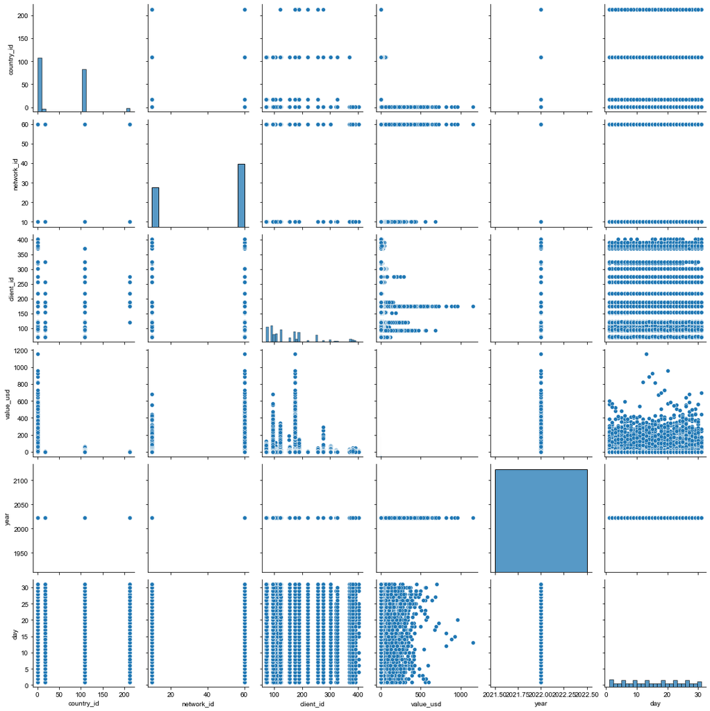

```python
sns.pairplot(df)
sns.set_style('dark')
plt.show()
```

```python
#A bar graph showing the total adspend per month in usd
```

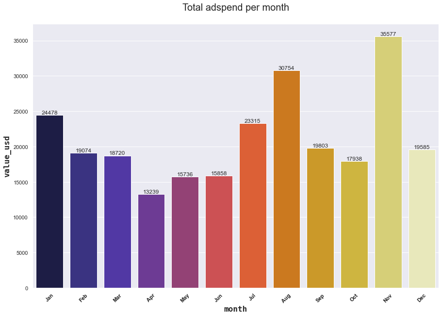

```python
plt.figure(figsize=(15,10))
sns.set()
ax=sns.barplot(x=df['month'],y=df['value_usd'],ci=None,palette='CMRmap',estimator=np.sum)
plt.xticks(rotation=60)
plt.title('Total adspend per month\n',fontsize=20)
ax.bar_label(ax.containers[0],fmt='%.f')
plt.xlabel('month' ,size=16, family='monospace', weight=900)
plt.ylabel('value_usd' ,size=16, family='monospace',weight=900)
plt.xticks(rotation=45,weight=600)
plt.savefig('adspend_month.png')
plt.show()
```

```python
#From the data november had the highest adspend at $35577
```

```python
#network id with the highest adspend value in usd
```

```python
df.groupby('network_id')['value_usd'].sum().sort_values(ascending=[False]).reset_index()
```

|  | network_id | value_usd |
| --- | --- | --- |
| 0 | 60 | 214838.614914 |
| 1 | 10 | 39237.360885 |

```python
#client id with the highest adspend value in usd
```

```python
t=df.groupby('client_id')['value_usd'].sum().sort_values(ascending=[False]).reset_index()
t
```

|  | client_id | value_usd |
| --- | --- | --- |
| 0 | 174 | 104606.688250 |
| 1 | 94 | 71636.985414 |
| 2 | 121 | 42158.106030 |
| 3 | 71 | 11021.333005 |
| 4 | 189 | 4474.769952 |
| 5 | 104 | 3187.530988 |
| 6 | 256 | 2968.805070 |
| 7 | 302 | 2631.670026 |
| 8 | 275 | 1998.470014 |
| 9 | 380 | 1764.217032 |
| 10 | 154 | 1201.680991 |
| 11 | 95 | 1029.802998 |
| 12 | 97 | 994.032014 |
| 13 | 374 | 919.767001 |
| 14 | 184 | 778.317013 |
| 15 | 370 | 473.887003 |
| 16 | 390 | 447.479988 |
| 17 | 152 | 380.630995 |
| 18 | 219 | 347.328007 |
| 19 | 73 | 339.920000 |
| 20 | 122 | 337.900008 |
| 21 | 321 | 133.649999 |
| 22 | 110 | 131.499999 |
| 23 | 402 | 64.660000 |
| 24 | 98 | 20.800000 |
| 25 | 325 | 16.300000 |
| 26 | 183 | 9.744000 |

```python
#top ten
```

```python
t.head(10)
```

|  | client_id | value_usd |
| --- | --- | --- |
| 0 | 174 | 104606.688250 |
| 1 | 94 | 71636.985414 |
| 2 | 121 | 42158.106030 |
| 3 | 71 | 11021.333005 |
| 4 | 189 | 4474.769952 |
| 5 | 104 | 3187.530988 |
| 6 | 256 | 2968.805070 |
| 7 | 302 | 2631.670026 |
| 8 | 275 | 1998.470014 |
| 9 | 380 | 1764.217032 |

```python
#country id with the highest adspend value in usd
```

```python
df.groupby('country_id')['value_usd'].sum().sort_values(ascending=[False]).reset_index()
```

|  | country_id | value_usd |
| --- | --- | --- |
| 0 | 1 | 243186.687782 |
| 1 | 109 | 10053.718011 |
| 2 | 213 | 501.178006 |
| 3 | 17 | 334.392000 |

```python
#country id ,client id and network work id with the highest value in usd
```

```python
df.groupby(['country_id','client_id','network_id'])['value_usd'].sum().sort_values(ascending=[False]).reset_index()
```

|  | country_id | client_id | network_id | value_usd |
| --- | --- | --- | --- | --- |
| 0 | 1 | 174 | 60 | 100549.353226 |
| 1 | 1 | 94 | 60 | 43361.647481 |
| 2 | 1 | 121 | 60 | 38394.565053 |
| 3 | 1 | 94 | 10 | 27895.079934 |
| 4 | 1 | 71 | 60 | 9717.570009 |
| ... | ... | ... | ... | ... |
| 95 | 17 | 94 | 60 | 0.200000 |
| 96 | 213 | 275 | 10 | 0.130000 |
| 97 | 1 | 402 | 10 | 0.110000 |
| 98 | 17 | 97 | 60 | 0.000000 |
| 99 | 17 | 73 | 60 | 0.000000 |

100 rows × 4 columns

```python
#country id ,client id and network work id with the highest value in usd (top ten)
```

```python
x=df.groupby(['country_id','client_id','network_id'])['value_usd'].sum().sort_values(ascending=[False]).reset_index()
x.head(10)
```

|  | country_id | client_id | network_id | value_usd |
| --- | --- | --- | --- | --- |
| 0 | 1 | 174 | 60 | 100549.353226 |
| 1 | 1 | 94 | 60 | 43361.647481 |
| 2 | 1 | 121 | 60 | 38394.565053 |
| 3 | 1 | 94 | 10 | 27895.079934 |
| 4 | 1 | 71 | 60 | 9717.570009 |
| 5 | 109 | 174 | 60 | 2937.835044 |
| 6 | 1 | 256 | 60 | 2649.202065 |
| 7 | 1 | 302 | 60 | 2607.600026 |
| 8 | 109 | 121 | 60 | 2332.569981 |
| 9 | 1 | 189 | 10 | 2148.549975 |

# Analysis on installs

```python
b
```

|  | install_id | country_id | app_id | network_id | event_date | device_os_version |
| --- | --- | --- | --- | --- | --- | --- |
| 0 | 6b168a9f7a13119b87bfeb834d159f6879ff000205cb27... | 1 | 174 | 26 | 2022-12-13 | 10 |
| 1 | 218ecd973c988fe76dfd247f92e9317485010844163a51... | 1 | 174 | 60 | 2022-12-14 | 10 |
| 2 | f67c1382fc3af8a24cb6f23bff381279d582eb67d4043e... | 17 | 122 | 26 | 2022-12-30 | 11 |
| 3 | afe4dc7c1663fba7ba3bc7cf6a308c38c1cb409d253f7f... | 1 | 121 | 1111 | 2022-12-30 | 8.0.0 |
| 4 | 417acac6a6bdb88a83371f8ab482691d16896e8681afcb... | 109 | 325 | 10 | 2022-12-05 | 11 |
| ... | ... | ... | ... | ... | ... | ... |
| 216883 | 19be0a9a4458de0d52547e141df90507cf6432ff8ac512... | 213 | 184 | 60 | 2022-01-08 | 10 |
| 216884 | a39a5e320f0cad2c67184302a1e5deeea9c12a1fa9a34d... | 109 | 121 | 60 | 2022-01-08 | 11 |
| 216885 | e6a9b7812608a10ba6a5c654e33ee2482a4e6cd4f9ec2f... | 109 | 121 | 26 | 2022-01-08 | 11 |
| 216886 | e0fd2cee99c16389dd64ba242471d5709f64033b03fb08... | 109 | 174 | 60 | 2022-01-08 | 10 |
| 216887 | d94f346409318fc80543a50254af51745fb8bf29ee0c4b... | 1 | 94 | 26 | 2022-01-08 | 10 |

216888 rows × 6 columns

```python
b['month'] = pd.DatetimeIndex(b['event_date']).month
b
```

|  | install_id | country_id | app_id | network_id | event_date | device_os_version | month |
| --- | --- | --- | --- | --- | --- | --- | --- |
| 0 | 6b168a9f7a13119b87bfeb834d159f6879ff000205cb27... | 1 | 174 | 26 | 2022-12-13 | 10 | 12 |
| 1 | 218ecd973c988fe76dfd247f92e9317485010844163a51... | 1 | 174 | 60 | 2022-12-14 | 10 | 12 |
| 2 | f67c1382fc3af8a24cb6f23bff381279d582eb67d4043e... | 17 | 122 | 26 | 2022-12-30 | 11 | 12 |
| 3 | afe4dc7c1663fba7ba3bc7cf6a308c38c1cb409d253f7f... | 1 | 121 | 1111 | 2022-12-30 | 8.0.0 | 12 |
| 4 | 417acac6a6bdb88a83371f8ab482691d16896e8681afcb... | 109 | 325 | 10 | 2022-12-05 | 11 | 12 |
| ... | ... | ... | ... | ... | ... | ... | ... |
| 216883 | 19be0a9a4458de0d52547e141df90507cf6432ff8ac512... | 213 | 184 | 60 | 2022-01-08 | 10 | 1 |
| 216884 | a39a5e320f0cad2c67184302a1e5deeea9c12a1fa9a34d... | 109 | 121 | 60 | 2022-01-08 | 11 | 1 |
| 216885 | e6a9b7812608a10ba6a5c654e33ee2482a4e6cd4f9ec2f... | 109 | 121 | 26 | 2022-01-08 | 11 | 1 |
| 216886 | e0fd2cee99c16389dd64ba242471d5709f64033b03fb08... | 109 | 174 | 60 | 2022-01-08 | 10 | 1 |
| 216887 | d94f346409318fc80543a50254af51745fb8bf29ee0c4b... | 1 | 94 | 26 | 2022-01-08 | 10 | 1 |

216888 rows × 7 columns

```python
b['day'] = pd.DatetimeIndex(b['event_date']).day
b
```

|  | install_id | country_id | app_id | network_id | event_date | device_os_version | month | day |
| --- | --- | --- | --- | --- | --- | --- | --- | --- |
| 0 | 6b168a9f7a13119b87bfeb834d159f6879ff000205cb27... | 1 | 174 | 26 | 2022-12-13 | 10 | 12 | 13 |
| 1 | 218ecd973c988fe76dfd247f92e9317485010844163a51... | 1 | 174 | 60 | 2022-12-14 | 10 | 12 | 14 |
| 2 | f67c1382fc3af8a24cb6f23bff381279d582eb67d4043e... | 17 | 122 | 26 | 2022-12-30 | 11 | 12 | 30 |
| 3 | afe4dc7c1663fba7ba3bc7cf6a308c38c1cb409d253f7f... | 1 | 121 | 1111 | 2022-12-30 | 8.0.0 | 12 | 30 |
| 4 | 417acac6a6bdb88a83371f8ab482691d16896e8681afcb... | 109 | 325 | 10 | 2022-12-05 | 11 | 12 | 5 |
| ... | ... | ... | ... | ... | ... | ... | ... | ... |
| 216883 | 19be0a9a4458de0d52547e141df90507cf6432ff8ac512... | 213 | 184 | 60 | 2022-01-08 | 10 | 1 | 8 |
| 216884 | a39a5e320f0cad2c67184302a1e5deeea9c12a1fa9a34d... | 109 | 121 | 60 | 2022-01-08 | 11 | 1 | 8 |
| 216885 | e6a9b7812608a10ba6a5c654e33ee2482a4e6cd4f9ec2f... | 109 | 121 | 26 | 2022-01-08 | 11 | 1 | 8 |
| 216886 | e0fd2cee99c16389dd64ba242471d5709f64033b03fb08... | 109 | 174 | 60 | 2022-01-08 | 10 | 1 | 8 |
| 216887 | d94f346409318fc80543a50254af51745fb8bf29ee0c4b... | 1 | 94 | 26 | 2022-01-08 | 10 | 1 | 8 |

216888 rows × 8 columns

```python
b['month']=b['month'].apply(lambda x:calendar.month_abbr[x])
b
```

|  | install_id | country_id | app_id | network_id | event_date | device_os_version | month | day |
| --- | --- | --- | --- | --- | --- | --- | --- | --- |
| 0 | 6b168a9f7a13119b87bfeb834d159f6879ff000205cb27... | 1 | 174 | 26 | 2022-12-13 | 10 | Dec | 13 |
| 1 | 218ecd973c988fe76dfd247f92e9317485010844163a51... | 1 | 174 | 60 | 2022-12-14 | 10 | Dec | 14 |
| 2 | f67c1382fc3af8a24cb6f23bff381279d582eb67d4043e... | 17 | 122 | 26 | 2022-12-30 | 11 | Dec | 30 |
| 3 | afe4dc7c1663fba7ba3bc7cf6a308c38c1cb409d253f7f... | 1 | 121 | 1111 | 2022-12-30 | 8.0.0 | Dec | 30 |
| 4 | 417acac6a6bdb88a83371f8ab482691d16896e8681afcb... | 109 | 325 | 10 | 2022-12-05 | 11 | Dec | 5 |
| ... | ... | ... | ... | ... | ... | ... | ... | ... |
| 216883 | 19be0a9a4458de0d52547e141df90507cf6432ff8ac512... | 213 | 184 | 60 | 2022-01-08 | 10 | Jan | 8 |
| 216884 | a39a5e320f0cad2c67184302a1e5deeea9c12a1fa9a34d... | 109 | 121 | 60 | 2022-01-08 | 11 | Jan | 8 |
| 216885 | e6a9b7812608a10ba6a5c654e33ee2482a4e6cd4f9ec2f... | 109 | 121 | 26 | 2022-01-08 | 11 | Jan | 8 |
| 216886 | e0fd2cee99c16389dd64ba242471d5709f64033b03fb08... | 109 | 174 | 60 | 2022-01-08 | 10 | Jan | 8 |
| 216887 | d94f346409318fc80543a50254af51745fb8bf29ee0c4b... | 1 | 94 | 26 | 2022-01-08 | 10 | Jan | 8 |

216888 rows × 8 columns

```python
#OS with the highest number of installs
```

```python
b['device_os_version'].value_counts().reset_index()
```

|  | index | device_os_version |
| --- | --- | --- |
| 0 | 11 | 79355 |
| 1 | 12 | 56679 |
| 2 | 10 | 45660 |
| 3 | 9 | 16285 |
| 4 | 8.0.0 | 5736 |
| ... | ... | ... |
| 76 | 15.1.1 | 1 |
| 77 | 4.9.227-22722052 | 1 |
| 78 | 12.1 | 1 |
| 79 | 14.7 | 1 |
| 80 | 4.9.227-21443963 | 1 |

81 rows × 2 columns

```python
#Top ten
```

```python
b['device_os_version'].value_counts().reset_index().head(10)
```

|  | index | device_os_version |
| --- | --- | --- |
| 0 | 11 | 79355 |
| 1 | 12 | 56679 |
| 2 | 10 | 45660 |
| 3 | 9 | 16285 |
| 4 | 8.0.0 | 5736 |
| 5 | 8.1.0 | 3894 |
| 6 | 13 | 2634 |
| 7 | 7.0 | 898 |
| 8 | 7.1.2 | 775 |
| 9 | 7.1.1 | 748 |

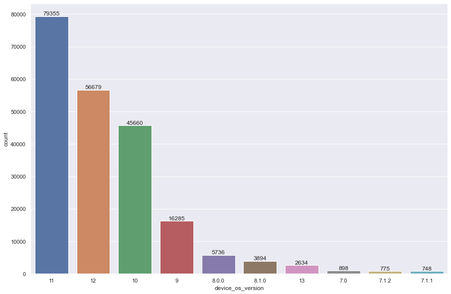

```python
sns.set()
plt.figure(figsize=(15,10))
ax=sns.countplot(x='device_os_version',data=b,order=pd.value_counts(b['device_os_version']).iloc[:10].index)
ax.bar_label(ax.containers[0],fmt='%.f')
plt.savefig('installs_per os.png')
```

```python
#Number of installs per month
```

```python
b['month'].value_counts().reset_index()
```

|  | index | month |
| --- | --- | --- |
| 0 | Aug | 30428 |
| 1 | Nov | 22732 |
| 2 | Jan | 21224 |
| 3 | Sep | 19945 |
| 4 | Dec | 19322 |
| 5 | Jul | 17844 |
| 6 | Oct | 17387 |
| 7 | Jun | 14906 |
| 8 | Feb | 14816 |
| 9 | Mar | 13518 |
| 10 | May | 13424 |
| 11 | Apr | 11342 |

```python
#Graphical reprsentation of the number of installs per month
```

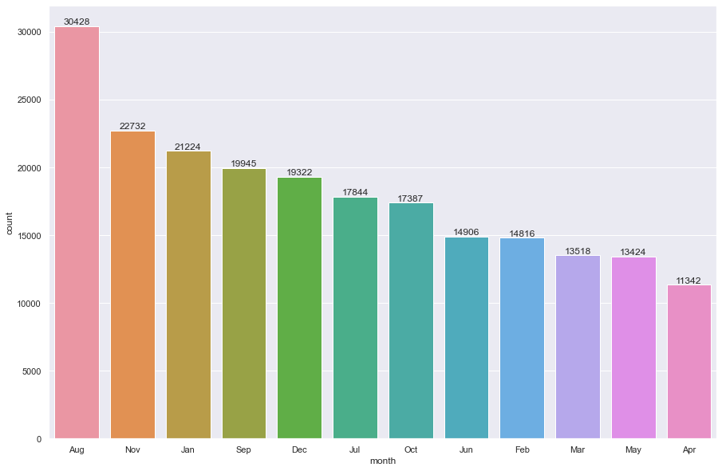

```python
sns.set()
plt.figure(figsize=(15,10))
ax=sns.countplot(x='month',data=b,order=b['month'].value_counts(ascending=False).index)
ax.bar_label(ax.containers[0],fmt='%.f')
plt.savefig('installs_permonth.png')
```